# Scenario analysis for the transmission and hospitalization of COVID-19 in the SW GA hospitals service area

May 06, 2020

## Introduction

This document provides a very rough estimate of the COVID-19 outbreak in the Southwest Georgia service area (not sure exactly how to describe this area).

To better understand the potential range of epidemic outcomes in the area, we used a model developed by the Center for the Ecology of Infectious Diseases at the University of Georgia based on data from Hubei Province, China calibrated to regionally specific conditions in Georgia. That Georgia-specific model was updated based on when the early cases in the ACC area began occurring.

More details about this model and its development can be found here:  
http://2019-coronavirus-tracker.com/stochastic-model.html

Calibration for Georgia can be found here:  
http://2019-coronavirus-tracker.com/stochastic-GA.html

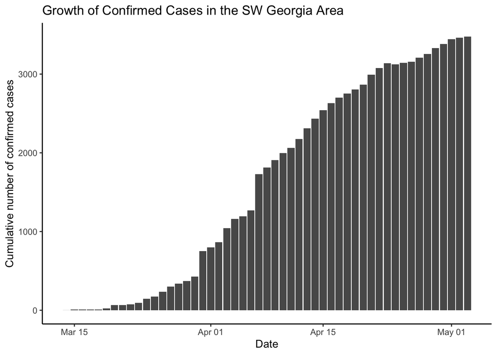

## The Models

Four basic models will be presented here. Each has been calibrated to fit the population size, date of the first confirmed case, and likely number of exposed (but not infectious) and infectious persons in the community when that first case was reported. A poor social distancing model will be included as the absolute worst-case scenario, with the basic assumption that social distancing interventions were never put into place. The other three models are calibrated to reflect the last month of case growth in this area. The first model assumes the calibrated reduction in transmission continues for the next four weeks. The second and third models assume that with the change in state policy related to sheltering in place, there is an increase in transmission that occurs beginning on April 25.

### The Poor Social Distancing Model

The following plot predicts the natural epidemic if allowed to spread with no measures put into place.

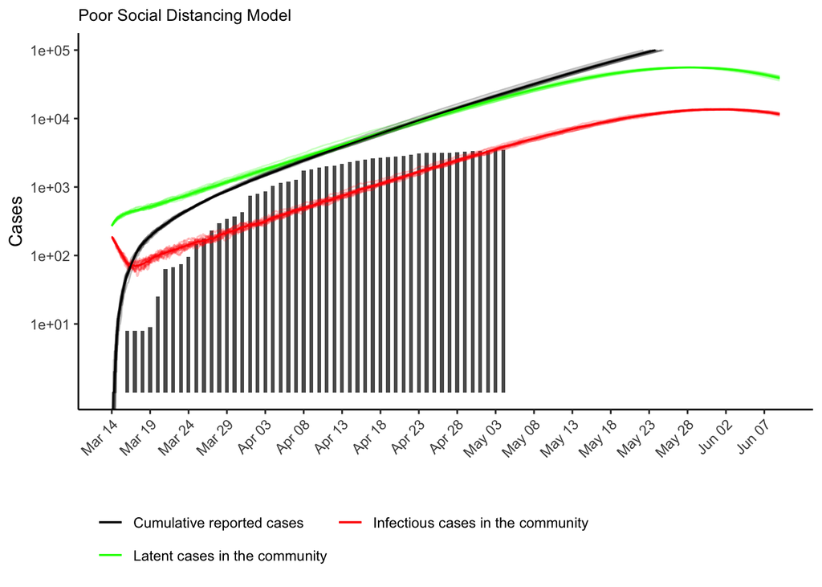

### The Calibrated Social Distancing Effect Model

The following plot calibrates transmission based on the likely impact of social distancing to this point and assumes that this level of intervention continues.

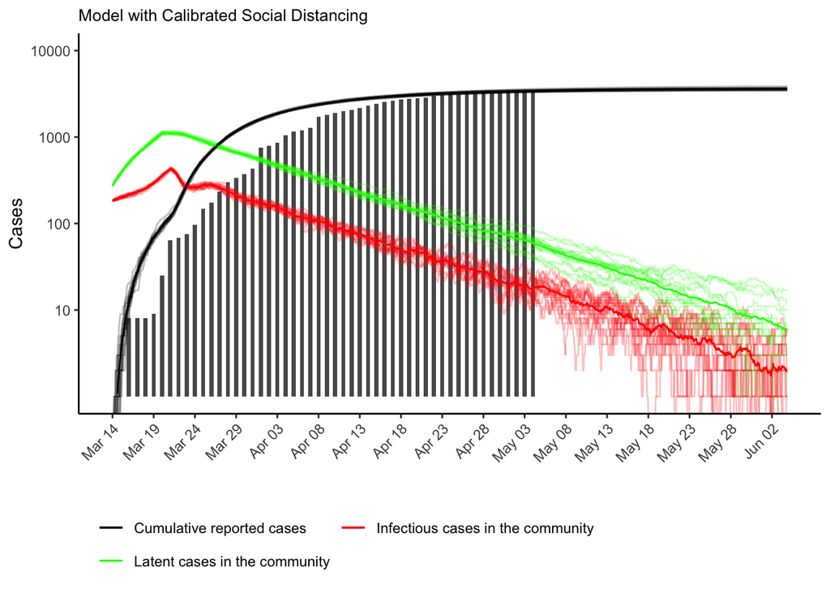

### The Calibrated Social Distancing Effect Models with Recent Increases in Transmission

The following plot predicts transmission with an increase in transmission based on recent state-level policy changes (call it the lower bound).

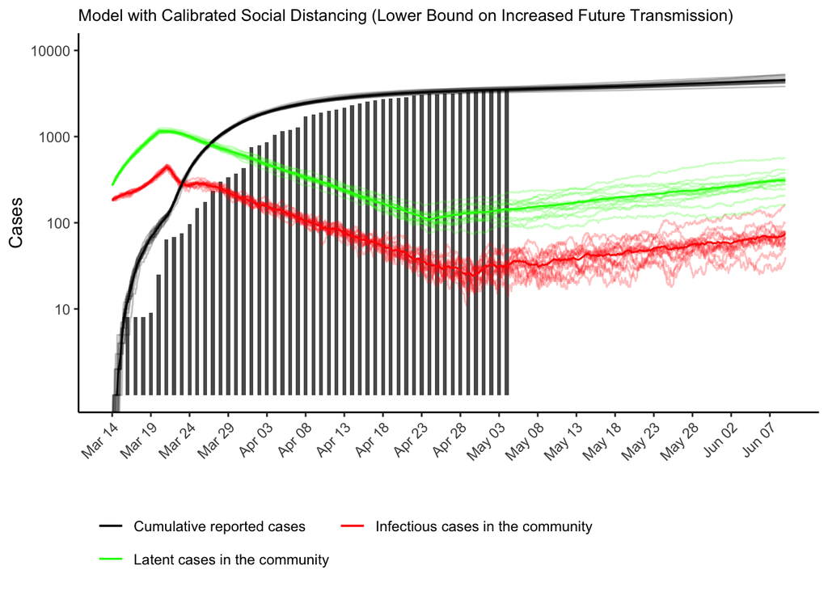

The following plot predicts transmission with an increase in transmission based on recent state-level policy changes (call it the upper bound).

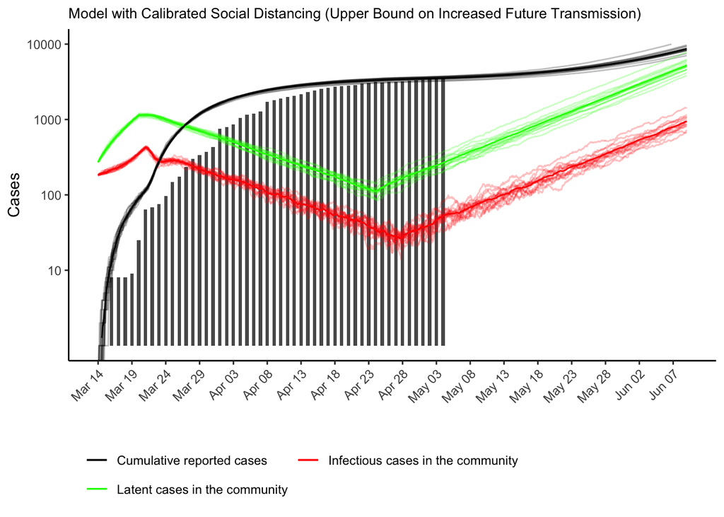